# 20200105菌絲體室10H6(裝風扇) VS 10H5溫度分析

Peter Lin

2020/1/9

#### 資料來源:

##### 1. 信億2020-01-05 提供之10H5/10H6 溫度數據 excel檔

##### 2. 中央氣象局觀測資料查詢網站

網址:http://e-service.cwb.gov.tw/HistoryDataQuery/DayDataController.do?command=viewMain&station=C0R480&stname=%25E9%2595%25B7%25E6%25B2%25BB&datepicker=2019-11-21

#### 初步結論:

1. 10H5 左右溫差0.59, 10H6 左右溫差0.15。加裝電扇可改善左右溫差大的問題。且 10H6之Cpk (左:1.02, 右:1.18) 優於 10H5之Cpk (左:0.82, 右:0.65)。 註: 如果10H6 右溫度去除2019-11-24 22.2C的異常值, Cpk可以達到1.35。
2. 從室外環境溫度與室內溫度的比較圖可看出,基本上室外環境溫度與室內溫度無太大關連性、 但特別注意的是此次資料只包含2019-11-21~ 2019-12-31的資料,此期間室外環境溫度大於30C的只有一天:2019-11-25(下午1:00), 而這一天剛好是10H6溫度最高的那一天。10H5卻沒有影響(不知道是溫度調控比較好還是方位的關係?)
3. 從中央氣象局2019年屏東縣長治鄉的室外環境溫度紀錄來看,4月到10月大多每天都會高於30C。2月,1月與12月則是日溫差(當日最大溫度-當日最低溫度)較大的月份。

#### 10H5 溫度分析

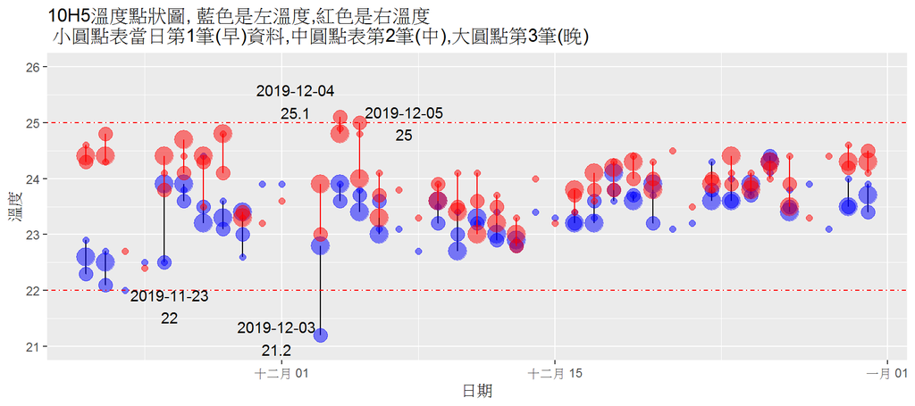

#### 10H6 溫度分析

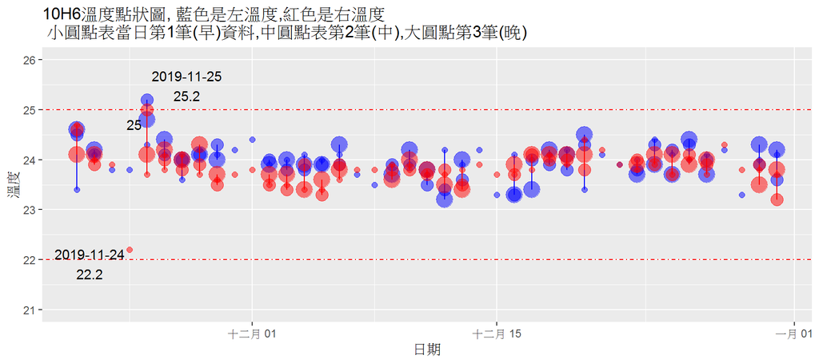

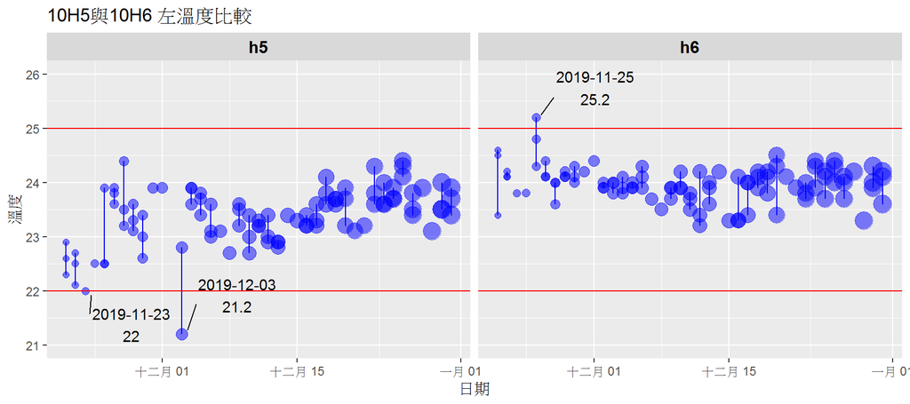

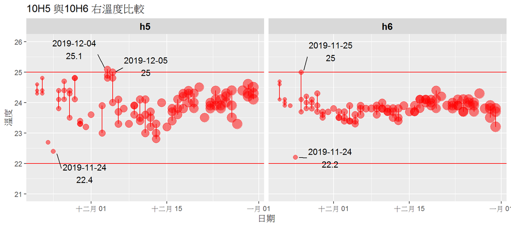

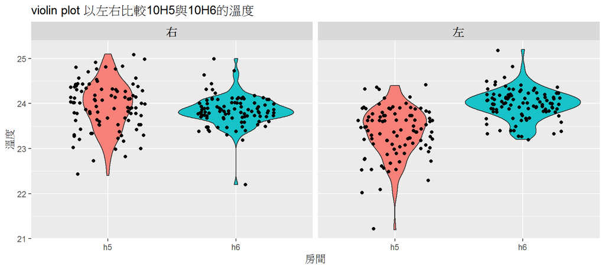

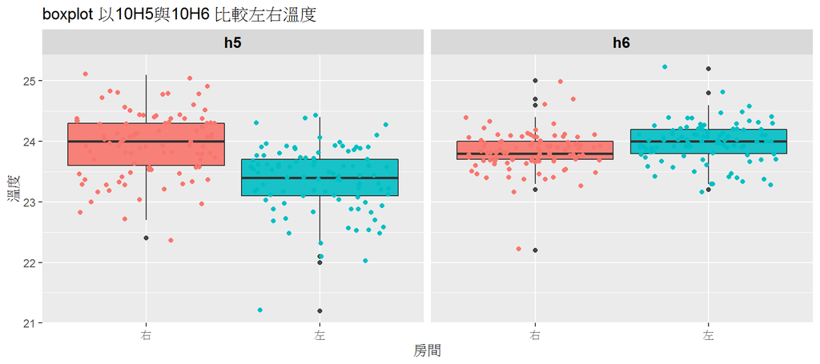

10H5 與 10H6 統計資料比較表

| item | H5_L | H5_R | H6_L | H6_R |
| --- | --- | --- | --- | --- |
| 平均溫度 | 23.36 | 23.95 | 23.98 | 23.83 |
| 標準差 | 0.55 | 0.54 | 0.33 | 0.33 |
| Cpk值 | 0.82 | 0.65 | 1.02 | 1.18 |

#### 2019-11-21 ~ 2019-12-31 室內與室外環境溫度(早中晚)比較圖

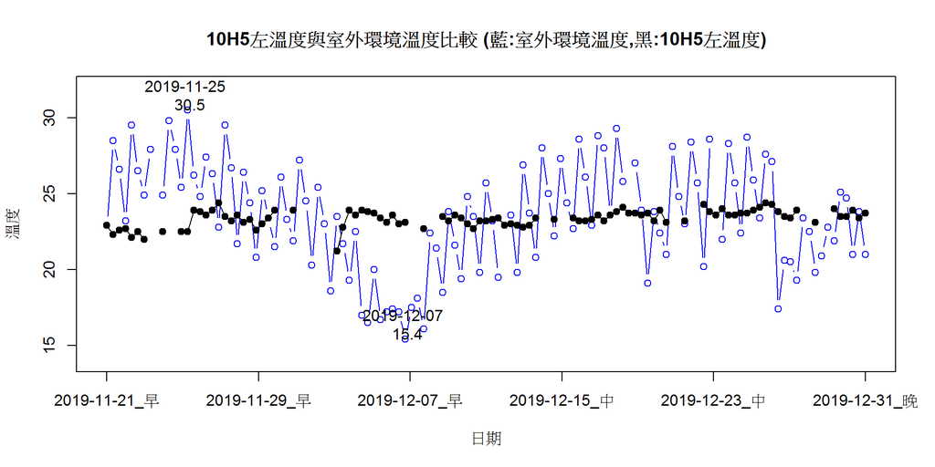

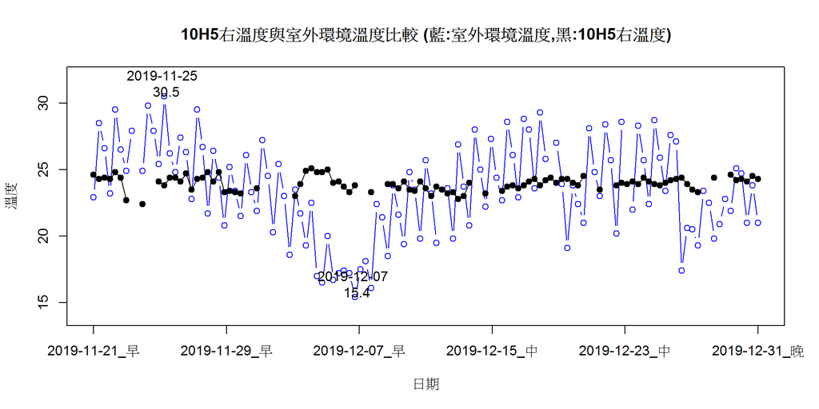

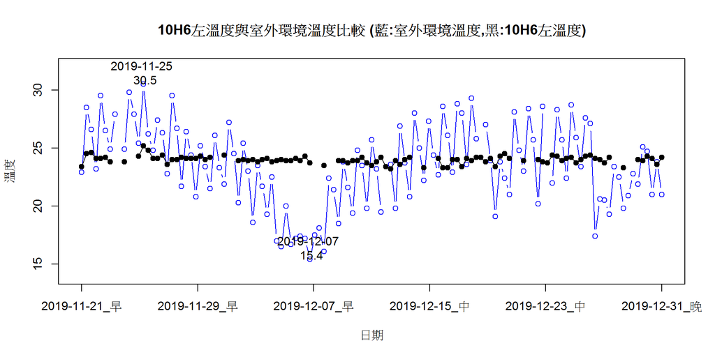

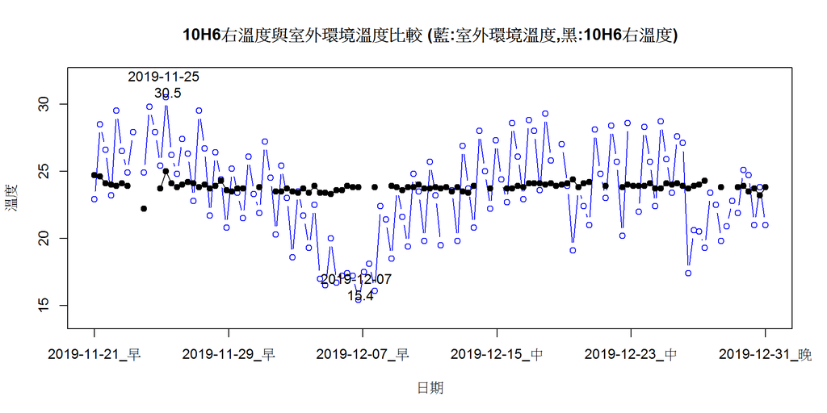

#### 屏東縣長治鄉2019年每小時溫度趨勢圖

[interactive chart not shown]

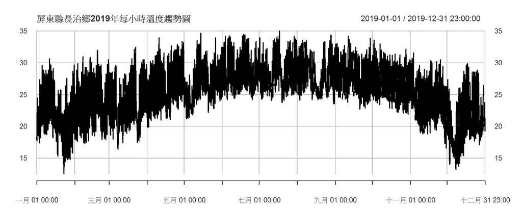

屏東縣長治鄉2019年各月份溫度超過30C的天數統計

| month | over_30_count |
| --- | --- |
| 1 | 1 |
| 2 | 5 |
| 3 | 6 |
| 4 | 23 |
| 5 | 17 |
| 6 | 27 |
| 7 | 25 |
| 8 | 23 |
| 9 | 28 |
| 10 | 25 |
| 11 | 7 |
| 12 | 0 |

#### 2019年屏東縣長治鄉

每月最高日溫差,最低日溫差與平均日溫差,並依平均日溫差大小排序

| month | max_diff_t | min_diff_t | average_diff_t |
| --- | --- | --- | --- |
| 2 | 12.3 | 4.6 | 9.70 |
| 1 | 12.9 | 4.2 | 8.92 |
| 12 | 13.3 | 2.9 | 8.84 |
| 3 | 11.9 | 4.1 | 8.58 |
| 4 | 12.1 | 3.8 | 8.53 |
| 11 | 11.4 | 3.9 | 8.31 |
| 10 | 10.0 | 5.5 | 7.39 |
| 9 | 10.4 | 4.6 | 7.21 |
| 6 | 9.6 | 4.1 | 7.09 |
| 7 | 9.5 | 3.2 | 6.81 |
| 5 | 10.4 | 1.7 | 6.54 |
| 8 | 8.8 | 1.9 | 6.07 |

#### 2019 屏東縣長治鄉每日最高溫, 最低溫 與日溫差(當日最高溫度-當日最低溫度)

|  | date | max_t | min_t | diff_t | month |
| --- | --- | --- | --- | --- | --- |
| 1 | 2019-01-01 | 24.5 | 17.7 | 6.8 | 1 |
| 2 | 2019-01-02 | 23.2 | 18.5 | 4.7 | 1 |
| 3 | 2019-01-03 | 27.4 | 17.4 | 10 | 1 |
| 4 | 2019-01-04 | 26.6 | 18.2 | 8.4 | 1 |
| 5 | 2019-01-05 | 29.6 | 20 | 9.6 | 1 |
| 6 | 2019-01-06 | 28.9 | 20.3 | 8.6 | 1 |
| 7 | 2019-01-07 | 28.3 | 18.8 | 9.5 | 1 |
| 8 | 2019-01-08 | 28.9 | 18.8 | 10.1 | 1 |
| 9 | 2019-01-09 | 28.3 | 18.7 | 9.6 | 1 |
| 10 | 2019-01-10 | 28.9 | 19.4 | 9.5 | 1 |

[output cut: 355 more lines]

[output not shown]

[output cut: 335 more lines]